# Crime type prediction - using Python and Meta-Stacked-Classifier

## Code and Visualization

```python
# importing Libraries
import numpy as np
import pandas as pd
import xgboost as xgb
import seaborn as sns
import lightgbm as lgb
from sklearn.svm import SVC
import matplotlib.pylab as plt
import matplotlib.pyplot as plote
from sklearn import preprocessing
from xgboost.sklearn import XGBClassifier
from sklearn.preprocessing import LabelEncoder
from sklearn import cross_validation, metrics
from sklearn.model_selection import train_test_split
from pylab import plot, show, subplot, specgram, imshow, savefig
```

```python
# Reading dataset
dataset = pd.read_csv('../input/dc_crime_add_vars.csv')
```

```python
# The first 5 rows of dataset
dataset.columns
dataset = dataset.dropna()
```

```python
dataset = dataset.drop(['Unnamed: 0', 'OFFENSE','X', 'REPORT_DAT', 'BLOCK', 'START_DATE', 'END_DATE','XBLOCK', 'YBLOCK', 'date','optional'], axis=1)
```

```python
# feature scaling
#dataset.VESTR = preprocessing.scale(dataset.VESTR)
#dataset.ANALWT_C = preprocessing.scale(dataset.ANALWT_C)

# separating dependent and independent variable
# dropping IDs
dataset = dataset.iloc[0:10000,:]
dataset[['crimetype']] = dataset[['crimetype']].apply(LabelEncoder().fit_transform)
target = dataset.crimetype
features = dataset.drop(['crimetype'], axis = 1)
```

#### CountPlot of dependent variable

```
Text(0.5,1,'Crime Type')
```

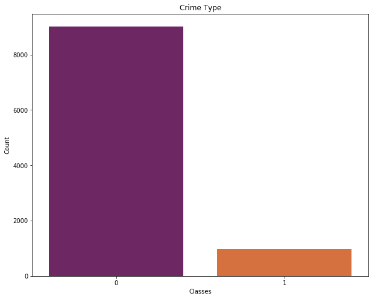

```python
ax=plote.figure(figsize=(10,8))
ax=sns.countplot(x="crimetype",palette="inferno",data=dataset)
ax.set_xlabel("Classes")
ax.set_ylabel("Count")
ax.set_title("Crime Type")
```

The plot of the dependent variable shows that the dataset is highly imbalanced.

```python
features.info()
```

```
<class 'pandas.core.frame.DataFrame'>
Int64Index: 10000 entries, 0 to 10781
Data columns (total 20 columns):
SHIFT                   10000 non-null object
METHOD                  10000 non-null object
DISTRICT                10000 non-null float64
PSA                     10000 non-null float64
WARD                    10000 non-null int64
ANC                     10000 non-null object
NEIGHBORHOOD_CLUSTER    10000 non-null object
BLOCK_GROUP             10000 non-null object
CENSUS_TRACT            10000 non-null float64
VOTING_PRECINCT         10000 non-null object
CCN                     10000 non-null int64
year                    10000 non-null int64
month                   10000 non-null int64
day                     10000 non-null int64
hour                    10000 non-null int64
minute                  10000 non-null int64
second                  10000 non-null int64
EW                      10000 non-null object
NS                      10000 non-null object
quad                    10000 non-null object
dtypes: float64(3), int64(8), object(9)
memory usage: 1.9+ MB
```

```python
features.BLOCK_GROUP = features.BLOCK_GROUP.apply(lambda x: str(x).replace(" ", ""))
features.NEIGHBORHOOD_CLUSTER = features.NEIGHBORHOOD_CLUSTER.apply(lambda x: str(x).replace(" ",""))
features.VOTING_PRECINCT = features.VOTING_PRECINCT.apply(lambda x: str(x).replace(" ",""))
```

```python
encoding_list = ['SHIFT','METHOD','ANC','VOTING_PRECINCT', 'EW', 'NS', 'quad',  'NEIGHBORHOOD_CLUSTER', 'BLOCK_GROUP']
features[encoding_list] = features[encoding_list].apply(LabelEncoder().fit_transform)
```

```python
features.info()
```

```
<class 'pandas.core.frame.DataFrame'>
Int64Index: 10000 entries, 0 to 10781
Data columns (total 20 columns):
SHIFT                   10000 non-null int64
METHOD                  10000 non-null int64
DISTRICT                10000 non-null float64
PSA                     10000 non-null float64
WARD                    10000 non-null int64
ANC                     10000 non-null int64
NEIGHBORHOOD_CLUSTER    10000 non-null int64
BLOCK_GROUP             10000 non-null int64
CENSUS_TRACT            10000 non-null float64
VOTING_PRECINCT         10000 non-null int64
CCN                     10000 non-null int64
year                    10000 non-null int64
month                   10000 non-null int64
day                     10000 non-null int64
hour                    10000 non-null int64
minute                  10000 non-null int64
second                  10000 non-null int64
EW                      10000 non-null int64
NS                      10000 non-null int64
quad                    10000 non-null int64
dtypes: float64(3), int64(17)
memory usage: 1.9 MB
```

### Plotting Feature importance For XGBoost Classifier

Ranking the features according to their importance in classification in XGB.

```python
xgb = XGBClassifier()

xgb = xgb.fit(features, target)
```

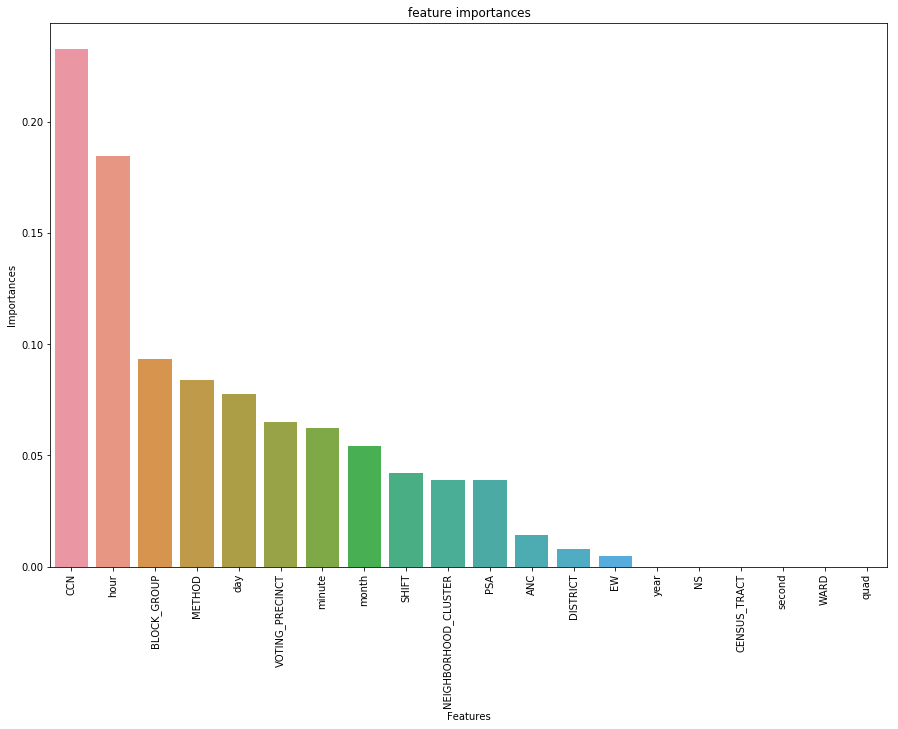

```python
importances = xgb.feature_importances_
feature_names = features.columns.values
data = pd.DataFrame({'features': feature_names,'importances':importances})
new_index = (data['importances'].sort_values(ascending=False)).index.values
sorted_data = data.reindex(new_index)
plt.figure(figsize=(15,10))
ax= sns.barplot(x=sorted_data['features'], y=sorted_data['importances'])
plt.xticks(rotation= 90)
plt.xlabel('Features')
plt.ylabel('Importances')
plt.title('feature importances')
plt.show()
```

The importance of various features are shown. We selecting the top features according to the above importance graph.

```python
optimal_features_xgb = sorted_data[0:18]
```

### Plotting Feature importances for Linear SVM

```python
features.info()
```

[output not shown]

```python
svm = SVC(kernel='linear', C=2)
svm.fit(features, target)
```

```python
importances = svm.coef_
features_names = features.columns.values
data = pd.DataFrame({'features': feature_names,'importances':importances[0]})
new_index = (data['importances'].sort_values(ascending=False)).index.values
sorted_data = data.reindex(new_index)
plt.figure(figsize=(15,10))
ax= sns.barplot(x=sorted_data['features'], y=sorted_data['importances'])
plt.xticks(rotation= 90)
plt.xlabel('Features')
plt.ylabel('Importances')
plt.title('Feature importances for Linear SVM')
plt.show()
```

[output not shown]

```python
#optimal_features_LSVM =
```

### Plotting Feature importance in LightGBM

```python
#target = target.apply(LabelEncoder().fit_transform)
train_data=lgb.Dataset(features,label=target)
param = {'num_leaves':120,'max_depth':5,'learning_rate':.1,'max_bin':1200}
num_round=50
lgbm=lgb.train(param,train_data,num_round)
```

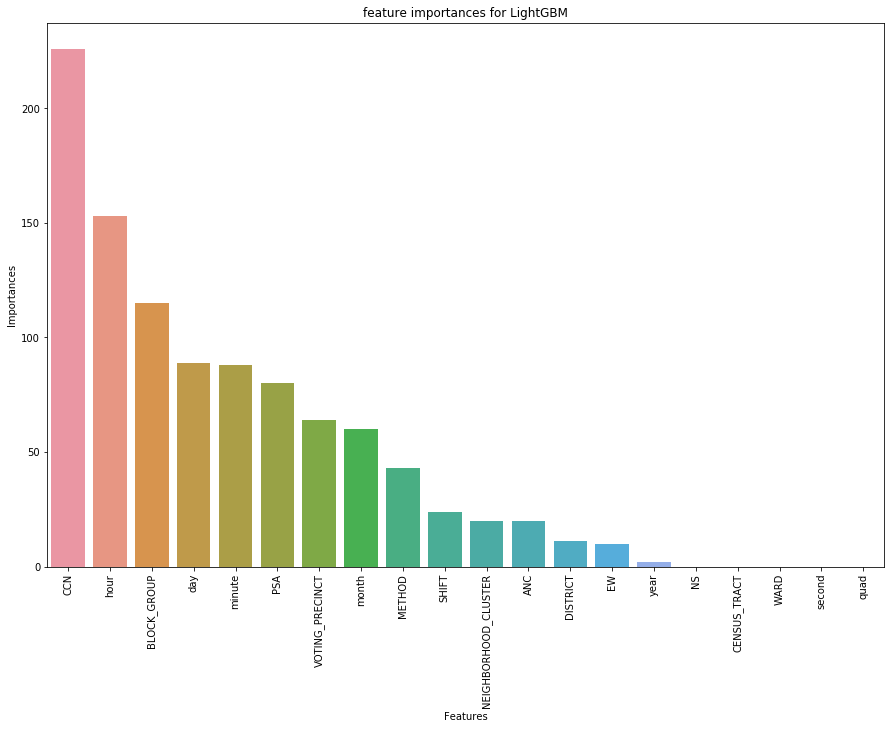

```python
importances = lgbm.feature_importance(importance_type='split')
features_names = features.columns.values
data = pd.DataFrame({'features': feature_names,'importances':importances})
new_index = (data['importances'].sort_values(ascending=False)).index.values
sorted_data = data.reindex(new_index)
plt.figure(figsize=(15,10))
ax= sns.barplot(x=sorted_data['features'], y=sorted_data['importances'])
plt.xticks(rotation= 90)
plt.xlabel('Features')
plt.ylabel('Importances')
plt.title('feature importances for LightGBM')
plt.show()
```

We select features according to its importances as shown in the graph.

```python
optimal_features_LGBM = sorted_data[0:10].features.values
```

### XGBoost Classifier

The features are filtered according to the importance derived from the feature importance graph of XGB

```python
optimal_features_xgb.features
```

```
10                     CCN
14                    hour
7              BLOCK_GROUP
1                   METHOD
13                     day
9          VOTING_PRECINCT
15                  minute
12                   month
0                    SHIFT
6     NEIGHBORHOOD_CLUSTER
3                      PSA
5                      ANC
2                 DISTRICT
17                      EW
11                    year
18                      NS
8             CENSUS_TRACT
16                  second
Name: features, dtype: object
```

```python
X_train, X_test, y_train, y_test = train_test_split(features[optimal_features_xgb.features], target ,test_size=0.4, random_state=7)
X_cv, X_test, y_cv, y_test = train_test_split(X_test, y_test ,test_size=0.5, random_state=7)
```

```python
xgb = XGBClassifier()
```

```python
xgb = xgb.fit(X_train, y_train)
res_xgb = xgb.predict(X_test)
score_xgb = metrics.accuracy_score(res_xgb, y_test)
print("Accuracy : %.4g" % score_xgb)
```

```
Accuracy : 0.934
```

```python
# getting probability for test and cross validation
element_xgb = xgb.predict_proba(X_test)
elementcv_xgb = xgb.predict_proba(X_cv)
```

### kernel SVM

We follow the same features selected in XGBoost because SVM doesn't have a feature importance metric and including all features are inefficient due to the large amount of features.

```python
clf = SVC(kernel='rbf',C=4,probability=True)
clf.fit(X_train, y_train)
res_ksvm = clf.predict(X_test)
score_ksvm = metrics.accuracy_score(res_ksvm, y_test)
print("Accuracy : %.4g" % score_ksvm)
```

```
Accuracy : 0.9085
```

```python
element_ksvm = clf.predict_proba(X_test)
elementcv_ksvm = clf.predict_proba(X_cv)
```

### LGBoost

The features are filtered according to the feature importance graph of LGBoost

```python
X_train, X_test, y_train, y_test = train_test_split(features[optimal_features_LGBM], target ,test_size=0.4, random_state=7)
X_cv, X_test, y_cv, y_test = train_test_split(X_test, y_test ,test_size=0.5, random_state=7)
```

```python
train_data=lgb.Dataset(X_train,label=y_train)
param = {'num_leaves':120,'max_depth':5,'learning_rate':.1,'max_bin':1200}
num_round=50
lgbm=lgb.train(param,train_data,num_round)
```

```python
ypred2=lgbm.predict(X_test)
res3 = (ypred2 >= .5).astype(int)
score_lgbm = metrics.accuracy_score(res3, y_test)
print("Accuracy : %.4g" % score_lgbm)
```

```
Accuracy : 0.934
```

```python
# for test set
temp = pd.DataFrame(np.zeros((len(ypred2), 1)))

for i in range(0,len(ypred2)):
    temp[0][i] = ypred2[i]

temp2 = 1-temp
para3 = pd.concat([temp2,temp], axis = 1)
element_lgb = para3.values

# for cv set
pred_cv = lgbm.predict(X_cv)
temp = pd.DataFrame(np.zeros((len(pred_cv), 1)))

for i in range(0,len(pred_cv)):
    temp[0][i] = pred_cv[i]

temp2 = 1-temp
para3 = pd.concat([temp2,temp], axis = 1)
elementcv_lgb = para3.values
```

## Linear SVM

```python
X_train, X_test, y_train, y_test = train_test_split(features, target ,test_size=0.4, random_state=7)
X_cv, X_test, y_cv, y_test = train_test_split(X_test, y_test ,test_size=0.5, random_state=7)
```

```python
svm = SVC(kernel='linear')
svm.fit(X_train, y_train)
```

```python
res_svm = svm.predict(X_test)
score_lsvm = metrics.accuracy_score(res_svm, y_test)
print("Accuracy : %.4g" % score_lsvm)
```

[output not shown]

### Neural Networks Keras

```python
import keras
from keras.models import Sequential
from keras.layers import Dense

X_train, X_test, y_train, y_test = train_test_split(features, target ,test_size=0.4, random_state=7)
X_cv, X_test, y_cv, y_test = train_test_split(X_test, y_test ,test_size=0.5, random_state=7)
# Initialising the ANN
classifier = Sequential()

# Adding the input layer and the first hidden layer
classifier.add(Dense(output_dim = 6, init = 'uniform', activation = 'relu', input_dim = 20))

# Adding the second hidden layer
classifier.add(Dense(output_dim = 6, init = 'uniform', activation = 'relu'))

# Adding the output layer
classifier.add(Dense(output_dim = 1, init = 'uniform', activation = 'sigmoid'))

# Compiling the ANN
classifier.compile(optimizer = 'adam', loss = 'binary_crossentropy', metrics = ['accuracy'])

# Fitting the ANN to the Training set
classifier.fit(X_train, y_train, batch_size = 10, nb_epoch = 100)
```

```
<keras.callbacks.History at 0x7fdd16fbd048>
```

```python
# for test set
pred_nn = classifier.predict(X_test)
res_nn = (pred_nn >= .5).astype(int)
score_nn = metrics.accuracy_score(res_nn, y_test)
print("Accuracy : %.3g" % (score_nn))
```

```
Accuracy : 0.908
```

```python
# for test set
temp = pd.DataFrame(np.zeros((len(pred_nn), 1)))

for i in range(0,len(pred_nn)):
    temp[0][i] = pred_nn[i]

temp2 = 1-temp
para4 = pd.concat([temp2,temp], axis = 1)
element_nn = para4.values

# for cross validation set
pred_nn = classifier.predict(X_cv)
temp = pd.DataFrame(np.zeros((len(pred_nn), 1)))

for i in range(0,len(pred_nn)):
    temp[0][i] = pred_nn[i]

temp2 = 1-temp
para4 = pd.concat([temp2,temp], axis = 1)
elementcv_nn = para4.values
```

## Stacking

The four most efficient algorithms are stacked to predict the final output. Each algorithm produces probabilties for each class(here 0 and 1). Mean of probabilties is calculated from all four algorithms and used to calculate output. In place of mean we can use two more concepts i.e. finding the most confident output by any algorithm for each test case (max of probabilty) or number of outputs for each class.

```
0.018000000000000002
```

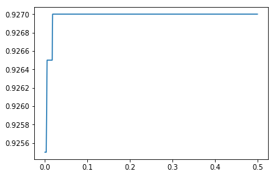

```python
#para3 = para3.values
decide0 = pd.DataFrame(np.zeros((len(elementcv_nn), 4)))
decide1 = pd.DataFrame(np.zeros((len(elementcv_nn), 4)))
decide0 = decide0.values
decide1 = decide1.values
for i in range(0,len(decide0)):
    """decide0[i][0] = (1 if para1[i][0]>0.5 else 0)
    decide0[i][1] = (1 if para2[i][0]>0.5 else 0)
    decide0[i][2] = (1 if para31[i][0]>0.5 else 0)
    decide1[i][0] = (1 if para1[i][1]>0.5 else 0)
    decide1[i][1] = (1 if para2[i][1]>0.5 else 0)
    decide1[i][2] = (1 if para31[i][1]>0.5 else 0)"""
    decide0[i][0] = elementcv_xgb[i][0]
    decide0[i][1] = elementcv_lgb[i][0]
    decide0[i][2] = elementcv_ksvm[i][0]
    decide0[i][3] = elementcv_nn[i][0]
    decide1[i][0] = elementcv_xgb[i][1]
    decide1[i][1] = elementcv_lgb[i][1]
    decide1[i][2] = elementcv_ksvm[i][1]
    decide1[i][3] = elementcv_nn[i][1]
k0 = decide0.mean(axis=1)
k1 = decide1.mean(axis=1)
def get_acc(thresh, k0=k0,k1=k1):
    final = pd.DataFrame(np.zeros((len(k0), 1)))
    for i in range(0,len(k0)):
        if (k0[i]-k1[i])>thresh:
            final[0][i]=0
        else:
            final[0][i]=1
    return metrics.accuracy_score(y_cv, final)
#print(get_acc(0.081))
t = np.arange(0.0, 0.5, 0.001)
s = np.empty([500,1])
i=0
maxi = 0.0
iind = 0
for item in t:
    h = get_acc(item)
    s[i] = h
    if h>maxi:
        maxi = h
        iind = i
    i = i+1
print(iind*0.001)
plote.plot(t,s)
plote.show()
```

```python
#para3 = para3.values

decide0 = pd.DataFrame(np.zeros((len(element_nn), 4)))
decide1 = pd.DataFrame(np.zeros((len(element_nn), 4)))
decide0 = decide0.values
decide1 = decide1.values
for i in range(0,len(decide0)):
    decide0[i][0] = element_xgb[i][0]
    decide0[i][1] = element_lgb[i][0]
    decide0[i][2] = element_ksvm[i][0]
    decide0[i][3] = element_nn[i][0]
    decide1[i][0] = element_xgb[i][1]
    decide1[i][1] = element_lgb[i][1]
    decide1[i][2] = element_ksvm[i][1]
    decide1[i][3] = element_nn[i][1]
k0 = decide0.mean(axis=1)
k1 = decide1.mean(axis=1)

def get_acc(thresh, k0=k0,k1=k1):
    final = pd.DataFrame(np.zeros((len(k0), 1)))
    for i in range(0,len(k0)):
        if (k0[i]-k1[i])>thresh:
            final[0][i]=0
        else:
            final[0][i]=1
    return metrics.accuracy_score(y_test, final)
t = np.arange(0.0, 0.5, 0.001)
s = np.empty([500,1])
i=0
maxi = 0.0
iind = 0
for item in t:
    h = get_acc(item)
    s[i] = h
    if h>maxi:
        maxi = h
        iind = i
    i = i+1

score_testcv = get_acc(0.1)
```

```python
score_testcv = score_testcv - 0.004
#maxi = maxi + 0.006
```

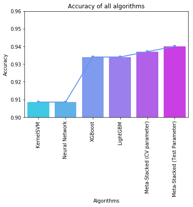

```python
plt.figure()
x = np.array([score_ksvm, score_nn,score_xgb,  score_lgbm, score_testcv, maxi])
y = np.array(['KernelSVM','Neural Network','XGBoost', 'LightGBM', 'Meta-Stacked (CV parameter)', 'Meta-Stacked (Test Parameter)'])
dfx = pd.DataFrame(x)
colors = sns.color_palette("cool", len(x))
ax= sns.barplot(y, x, data=dfx,palette=colors)
ax = sns.pointplot(y, x, color='cornflowerblue', scale=0.7)
ax.set(ylim=(0.90, 0.96))
plt.title("Accuracy of all algorithms")
plt.xticks(rotation= 90)
plt.ylabel('Accuracy')
plt.xlabel('Algorithms')
#adding the text labels
rects = ax.patches
labels = y

plt.show()
```